# Cerebral Stroke Diagnosis based on physiological Factors

TEAM 6

2022-10-27

# Exploratory data analysis

## Cerebral stroke diagnosis dataset

### Importing all the relevant packages

```r
#install packages
#remotes::install_github("cran/DMwR")
#install.packages("moments")
#install.packages("DataExplorer")

#import libraries all
library(ggplot2)
library(moments)
library(dplyr)
library(DMwR)
library(SmartEDA)
library(DataExplorer)
library(tidyverse)
library("corrplot")
```

### Importing our dataset

```r
#importing brain dataset
data <- data.frame(read.csv("dataset.csv"))


#checking the structure of our dataset
str(data)
```

```
## 'data.frame':    43400 obs. of  12 variables:
##  $ id               : int  30669 30468 16523 56543 46136 32257 52800 41413 15266 28674 ...
##  $ gender           : chr  "Male" "Male" "Female" "Female" ...
##  $ age              : num  3 58 8 70 14 47 52 75 32 74 ...
##  $ hypertension     : int  0 1 0 0 0 0 0 0 0 1 ...
##  $ heart_disease    : int  0 0 0 0 0 0 0 1 0 0 ...
##  $ ever_married     : chr  "No" "Yes" "No" "Yes" ...
##  $ work_type        : chr  "children" "Private" "Private" "Private" ...
##  $ Residence_type   : chr  "Rural" "Urban" "Urban" "Rural" ...
##  $ avg_glucose_level: num  95.1 88 110.9 69 161.3 ...
##  $ bmi              : num  18 39.2 17.6 35.9 19.1 50.1 17.7 27 32.3 54.6 ...
##  $ smoking_status   : chr  "" "never smoked" "" "formerly smoked" ...
##  $ stroke           : int  0 0 0 0 0 0 0 0 0 0 ...
```

```r
#since ID won't be useful during prediction so removing that
brainData <- select(data, -c('id'))

#checking top5 entries in our dataset
head(brainData)
```

```
##   gender age hypertension heart_disease ever_married    work_type
## 1   Male   3            0             0           No     children
## 2   Male  58            1             0          Yes      Private
## 3 Female   8            0             0           No      Private
## 4 Female  70            0             0          Yes      Private
## 5   Male  14            0             0           No Never_worked
## 6 Female  47            0             0          Yes      Private
##   Residence_type avg_glucose_level  bmi  smoking_status stroke
## 1          Rural             95.12 18.0                      0
## 2          Urban             87.96 39.2    never smoked      0
## 3          Urban            110.89 17.6                      0
## 4          Rural             69.04 35.9 formerly smoked      0
## 5          Rural            161.28 19.1                      0
## 6          Urban            210.95 50.1                      0
```

### Checking the summary of our dataset

```r
summary(brainData)
```

```
##     gender               age         hypertension     heart_disease
##  Length:43400       Min.   : 0.08   Min.   :0.00000   Min.   :0.00000
##  Class :character   1st Qu.:24.00   1st Qu.:0.00000   1st Qu.:0.00000
##  Mode  :character   Median :44.00   Median :0.00000   Median :0.00000
##                     Mean   :42.22   Mean   :0.09357   Mean   :0.04751
##                     3rd Qu.:60.00   3rd Qu.:0.00000   3rd Qu.:0.00000
##                     Max.   :82.00   Max.   :1.00000   Max.   :1.00000
##
##  ever_married        work_type         Residence_type     avg_glucose_level
##  Length:43400       Length:43400       Length:43400       Min.   : 55.00
##  Class :character   Class :character   Class :character   1st Qu.: 77.54
##  Mode  :character   Mode  :character   Mode  :character   Median : 91.58
##                                                           Mean   :104.48
##                                                           3rd Qu.:112.07
##                                                           Max.   :291.05
##
##       bmi        smoking_status         stroke
##  Min.   :10.10   Length:43400       Min.   :0.00000
##  1st Qu.:23.20   Class :character   1st Qu.:0.00000
##  Median :27.70   Mode  :character   Median :0.00000
##  Mean   :28.61                      Mean   :0.01804
##  3rd Qu.:32.90                      3rd Qu.:0.00000
##  Max.   :97.60                      Max.   :1.00000
##  NA's   :1462
```

## Q-Q Plot to check normality of Numeric Variables

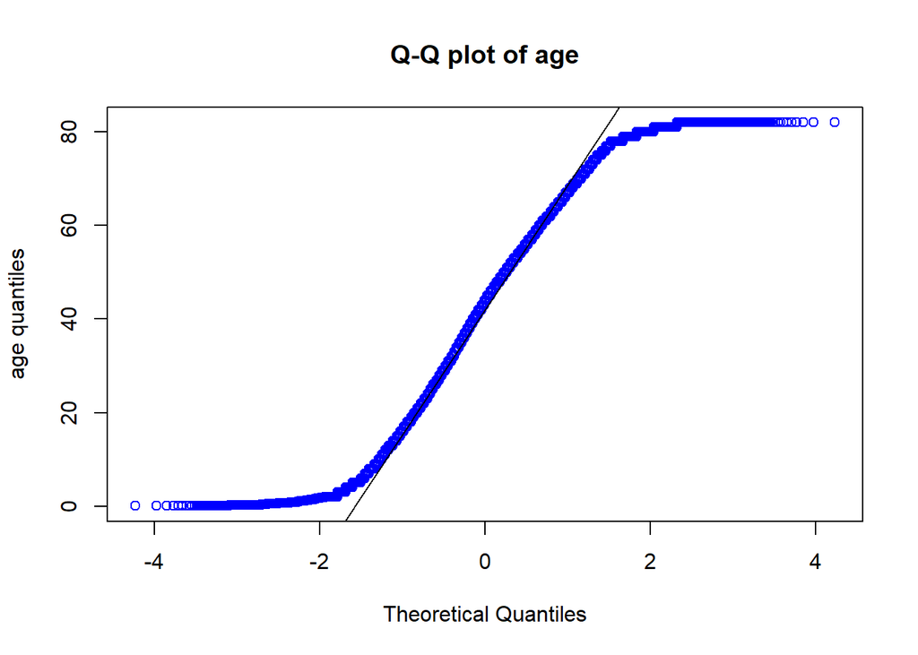

```r
qqnorm(brainData$age, main="Q-Q plot of age", col="blue", ylab="age quantiles")
qqline(brainData$age)
```

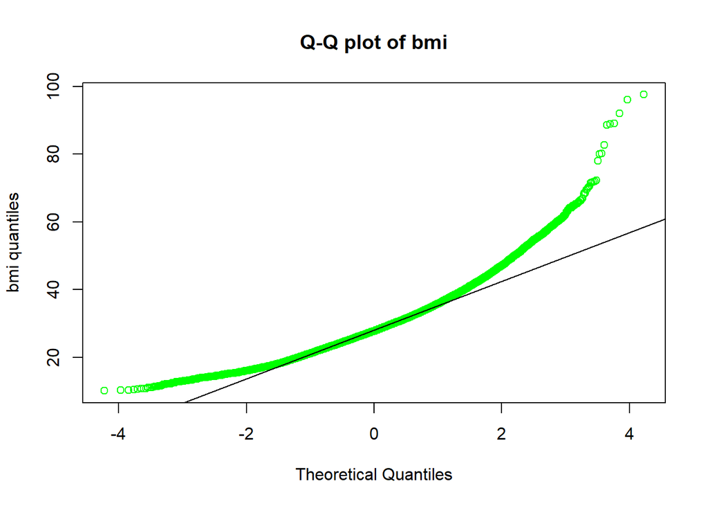

```r
qqnorm(brainData$bmi, main="Q-Q plot of bmi", col="green", ylab="bmi quantiles")
qqline(brainData$bmi)
```

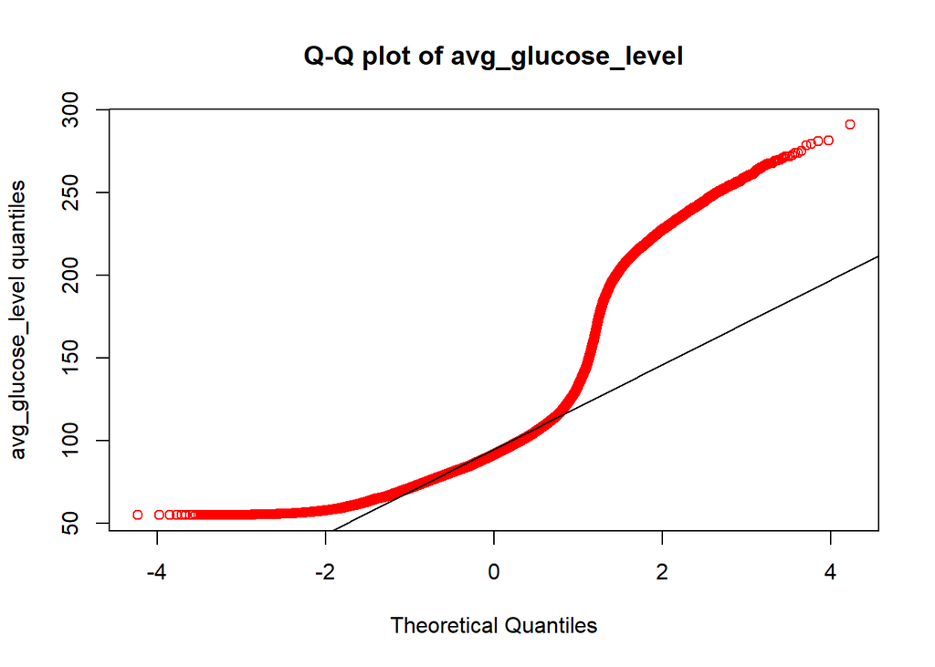

```r
qqnorm(brainData$avg_glucose_level, main="Q-Q plot of avg_glucose_level", col="red", ylab="avg_glucose_level quantiles")
qqline(brainData$avg_glucose_level)
```

Age distribution is close to normal distribution  
BMI is close to normal distribution with few outliers  
Average Glucose curve is not very close to normal distribution

Since most of the variables are categorical, converting them to factors.

```r
#Converting gender,hypertension,heart_disease,ever_married,work_type,Residence_type,smoking_status,stroke to factors
brainData$gender = factor(brainData$gender)
brainData$hypertension = factor(brainData$hypertension)
brainData$heart_disease = factor(brainData$heart_disease)
brainData$ever_married = factor(brainData$ever_married)
brainData$work_type = factor(brainData$work_type)
brainData$Residence_type = factor(brainData$Residence_type)
brainData$smoking_status = factor(brainData$smoking_status)
brainData$stroke = factor(brainData$stroke)
str(brainData)
```

```
## 'data.frame':    43400 obs. of  11 variables:
##  $ gender           : Factor w/ 3 levels "Female","Male",..: 2 2 1 1 2 1 1 1 1 1 ...
##  $ age              : num  3 58 8 70 14 47 52 75 32 74 ...
##  $ hypertension     : Factor w/ 2 levels "0","1": 1 2 1 1 1 1 1 1 1 2 ...
##  $ heart_disease    : Factor w/ 2 levels "0","1": 1 1 1 1 1 1 1 2 1 1 ...
##  $ ever_married     : Factor w/ 2 levels "No","Yes": 1 2 1 2 1 2 2 2 2 2 ...
##  $ work_type        : Factor w/ 5 levels "children","Govt_job",..: 1 4 4 4 3 4 4 5 4 5 ...
##  $ Residence_type   : Factor w/ 2 levels "Rural","Urban": 1 2 2 1 1 2 2 1 1 2 ...
##  $ avg_glucose_level: num  95.1 88 110.9 69 161.3 ...
##  $ bmi              : num  18 39.2 17.6 35.9 19.1 50.1 17.7 27 32.3 54.6 ...
##  $ smoking_status   : Factor w/ 4 levels "","formerly smoked",..: 1 3 1 2 1 1 2 3 4 3 ...
##  $ stroke           : Factor w/ 2 levels "0","1": 1 1 1 1 1 1 1 1 1 1 ...
```

```r
summary(brainData)
```

```
##     gender           age        hypertension heart_disease ever_married
##  Female:25665   Min.   : 0.08   0:39339      0:41338       No :15462
##  Male  :17724   1st Qu.:24.00   1: 4061      1: 2062       Yes:27938
##  Other :   11   Median :44.00
##                 Mean   :42.22
##                 3rd Qu.:60.00
##                 Max.   :82.00
##
##          work_type     Residence_type avg_glucose_level      bmi
##  children     : 6156   Rural:21644    Min.   : 55.00    Min.   :10.10
##  Govt_job     : 5440   Urban:21756    1st Qu.: 77.54    1st Qu.:23.20
##  Never_worked :  177                  Median : 91.58    Median :27.70
##  Private      :24834                  Mean   :104.48    Mean   :28.61
##  Self-employed: 6793                  3rd Qu.:112.07    3rd Qu.:32.90
##                                       Max.   :291.05    Max.   :97.60
##                                                         NA's   :1462
##          smoking_status  stroke
##                 :13292   0:42617
##  formerly smoked: 7493   1:  783
##  never smoked   :16053
##  smokes         : 6562
##
##
##
```

### Class Imbalance

Unequal distribution of data might result in inaccurate calculations for accuracy and thus we need to balance our dataset before proceeding further.  
So we wil remove the missing values and then use Sampling Techniques to balance our dataset.

Checking Box Plots to visualize numeric variables

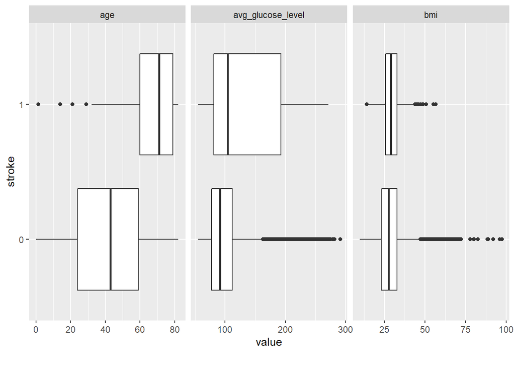

```r
#concise box plot for numeric variables
plot_boxplot(brainData, by = "stroke")
```

### Cleaning the dataset : Smoking Status, Gender, BMI

Removing missing Values from smoking status

```r
cleanData = brainData
cleanData[cleanData == ''] <- NA
nrow(cleanData)
```

```
## [1] 43400
```

```r
cleanData <- subset(cleanData, !is.na(smoking_status))
nrow(cleanData)
```

```
## [1] 30108
```

```r
table(cleanData$gender)
```

```
##
## Female   Male  Other
##  18366  11733      9
```

Since other gender entries are very less, we will just drop the other rows.

```r
drop_others = subset(cleanData, cleanData$gender != 'Other')
table(drop_others$gender)
```

```
##
## Female   Male  Other
##  18366  11733      0
```

```r
cleanData <- drop_others
```

Analysis for BMI NULL values.

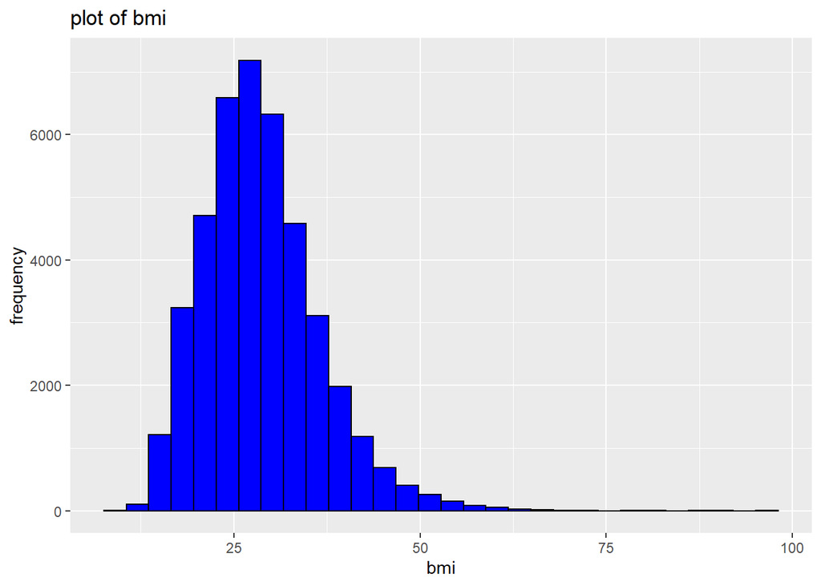

```r
ggplot(data=brainData, aes(bmi)) +
geom_histogram(col="black",
fill="blue") +
labs(x="bmi", y="frequency") +
labs(title="plot of bmi")
```

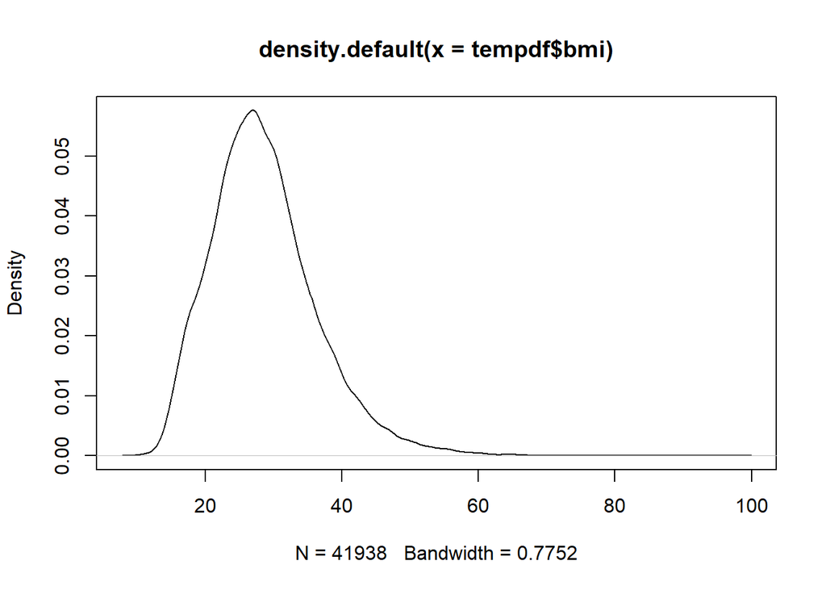

```r
tempdf <- subset(brainData, !is.na(bmi))  # removing NA values from bmi and storing it in tempdf
density_bmi <- density(tempdf$bmi)
plot(density_bmi)    #plotting the density curve of bmi values
```

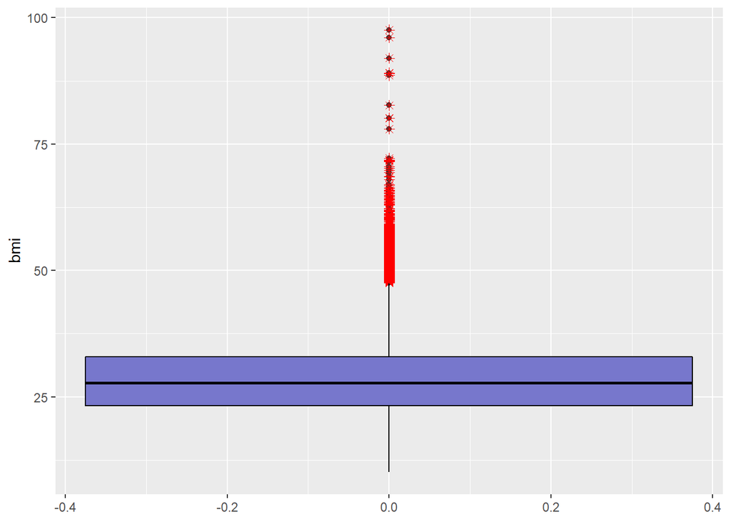

```r
ggplot(data = tempdf, mapping = aes(y = bmi)) +
  geom_boxplot() + geom_boxplot( colour="black", fill="#7777cc", outlier.colour="red", outlier.shape=8, outlier.size=2)  #plotting the boxplot for bmi values.
```

```r
skewness_value <- skewness(tempdf$bmi)
```

Skewness value: 0.8986961

From the density curve and skewness value, BMI is rightly skewed. So mean is not the right central tendency to fill NA values in BMI. We will NA values in BMI using median of the data. Note: Negative skewness value indicates left skewed and positive skewness value indicates right skewed. The rule of thumb seems to be:

If the skewness is between -0.5 and 0.5, the data are fairly symmetrical If the skewness is between -1 and – 0.5 or between 0.5 and 1, the data are moderately skewed If the skewness is less than -1 or greater than 1, the data are highly skewed

Replacing Missing Values for BMI with median.

```r
#removing missing values for BMI
cleanData$bmi[is.na(cleanData$bmi)] <- median(cleanData$bmi, na.rm = T) #replacing NA values with median of the remaining bmi values.
summary(cleanData)
```

```
##     gender           age        hypertension heart_disease ever_married
##  Female:18366   Min.   :10.00   0:26571      0:28421       No : 7551
##  Male  :11733   1st Qu.:33.00   1: 3528      1: 1678       Yes:22548
##  Other :    0   Median :48.00
##                 Mean   :47.94
##                 3rd Qu.:62.00
##                 Max.   :82.00
##          work_type     Residence_type avg_glucose_level      bmi
##  children     :  629   Rural:14977    Min.   : 55.01    Min.   :10.10
##  Govt_job     : 4345   Urban:15122    1st Qu.: 77.84    1st Qu.:25.10
##  Never_worked :  101                  Median : 92.40    Median :28.90
##  Private      :19579                  Mean   :107.19    Mean   :30.02
##  Self-employed: 5445                  3rd Qu.:114.50    3rd Qu.:33.60
##                                       Max.   :291.05    Max.   :92.00
##          smoking_status  stroke
##                 :    0   0:29461
##  formerly smoked: 7487   1:  638
##  never smoked   :16051
##  smokes         : 6561
##
##
```

### Removing outliers : BMI

Removing Outliers for BMI

```r
dim(cleanData)
```

```
## [1] 30099    11
```

```r
quartiles_bmi <- quantile(cleanData$bmi, probs=c(.25, .75), na.rm = FALSE)
IQR_bmi <- IQR(cleanData$bmi)


Lower_bmi <- quartiles_bmi[1] - 1.5*IQR_bmi
Upper_bmi <- quartiles_bmi[2] + 1.5*IQR_bmi

#since all the missing values are for stroke =0 entries, we will directly drop it

cleanData <- subset(cleanData, cleanData$bmi > Lower_bmi & cleanData$bmi < Upper_bmi)

dim(cleanData)
```

```
## [1] 29224    11
```

**Outliers for Age and Average Glucose Level**  
We won’t be removing Outliers for Age and Average level because  
1) max value of age is 82, so nothing is unusual about that  
2)avg_glucose_level is losing the relationship with stroke if we remove the outliers  
When we try to upsample that difference is even more nullified

**Average Glucose Level into 3 Diabetic Group** Making a separate column for average glucose level  
Here as we can see, **people who have diabetes are more likely to get stroke.**

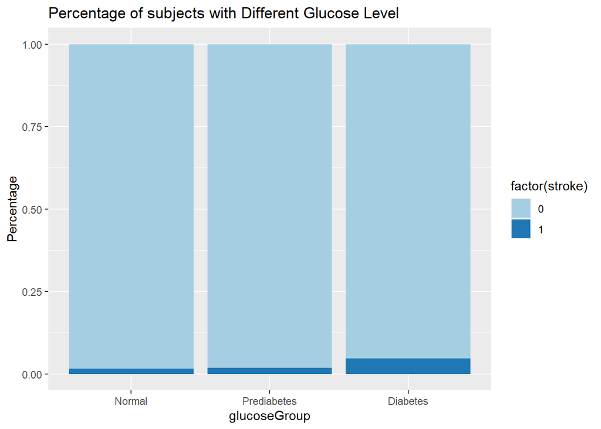

```r
cleanData$glucoseGroup=cut(cleanData$avg_glucose_level, c(0, 114, 140, Inf), c("Normal", "Prediabetes", "Diabetes"), include.lowest=TRUE)
#0-114 : Normal glucose level
#114-140 : Prediabetes
#140- infinity : Diabetes

#glucoseGroup to stroke relations
#ggbarstats(data=cleanData,y=glucoseGroup,x=stroke,label="both")
#people with diabetes have a high chance of getting stroke
df_glucose <- cleanData %>%
  group_by(glucoseGroup, stroke) %>%
  count(stroke)
#grouping data into three glucose level

df_glucose %>%
ggplot(mapping = aes(x = glucoseGroup, y = n, fill = factor(stroke))) +
  geom_bar(stat = "identity", position = "fill") +
  labs(title = "Percentage of subjects with Different Glucose Level",
       x = "glucoseGroup",
       y = "Percentage") +
  scale_fill_brewer(palette = "Paired")
```

### Synthetic Minority Over-Sampling Technique(SMOTE): Upsampling of data

SMOTE is an intelligent upsampling technique that focuses on creating the new entries along the lines of a randomly chosen point and its nearest neighbors(to avoid overfitting). This is better than blindly duplicating values since it gives some variation as well.

```r
table(cleanData$stroke)
```

```
##
##     0     1
## 28597   627
```

```r
#use SMOTE to create new dataset that is more balanced
cleanData <- SMOTE(stroke ~ ., cleanData, perc.over = 2000, perc.under = 200)
#minority => 2000/100 =20 so 20*(strok1Observations=416) #upsampling
#200/100 =2, make the majority observation 2 time the minority observations #downsampling

#view distribution of response variable in new dataset
table(cleanData$stroke)
```

```
##
##     0     1
## 25080 13167
```

### BMI analysis

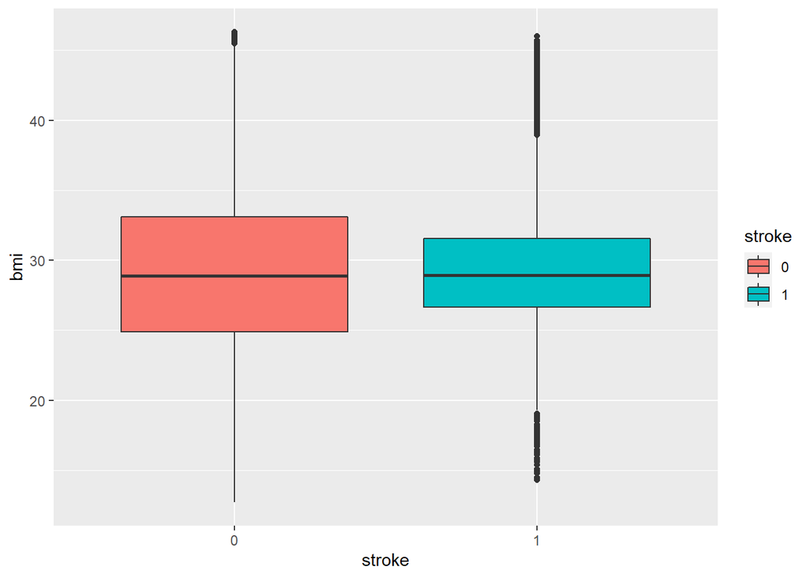

```r
ggplot(data = cleanData, mapping = aes(x = stroke, y = bmi, fill=stroke)) +
  geom_boxplot()
```

The above box plot is not giving us anything concrete about stroke prediction. Since for both distributions with and without stroke, the average BMI is almost similar.  
The 3rd Quartile value for stroke = 1 is slightly less which contradicts the medical results that high BMI people are more prone to getting Stroke.

### BMI versus stroke for different Genders

Distribution for both the Gender is still similar only for BMI.

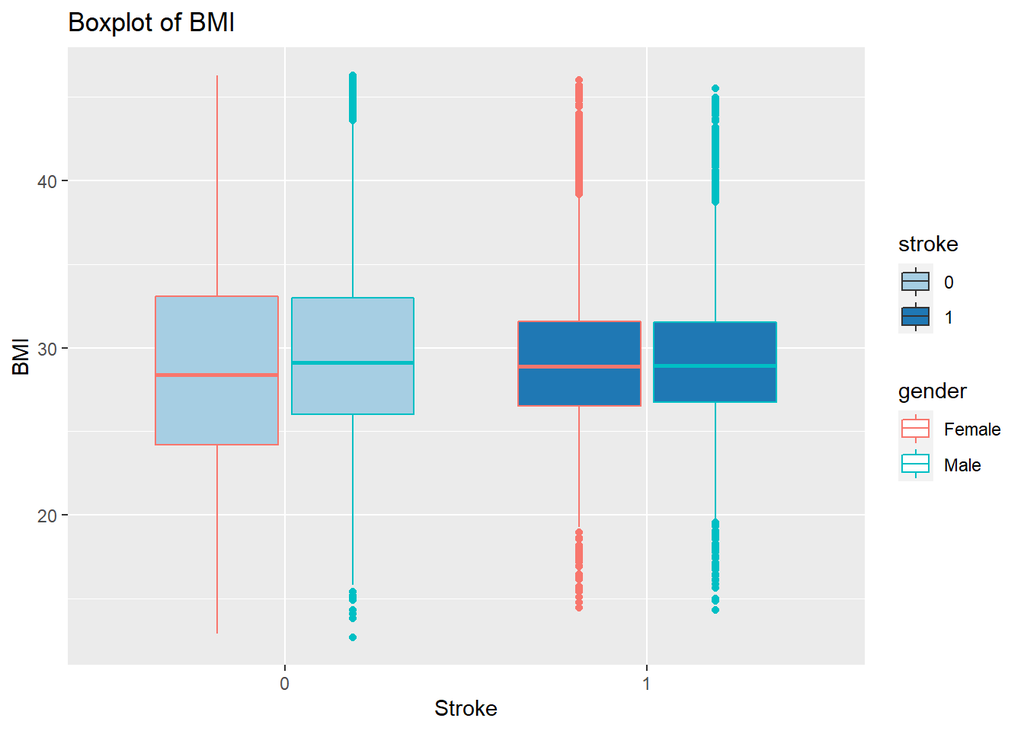

```r
ggplot(data = cleanData, mapping = aes(x = stroke, y = bmi, fill = stroke, color = gender)) +
  geom_boxplot() +
  labs(title = "Boxplot of BMI",
       x = "Stroke",
       y = "BMI") +
  scale_fill_brewer(palette = "Paired")
```

From the box plots above, there is no strong evidence of subjects having stroke with respect to BMI and gender.

### Glucose level analysis

**Average Glucose Level**

Secondly, since glucoseGroup was formed based on avg_glucose_level, SMOTE being unaware of the cutoffs for Normal, Prediabetes and Diabetes didn’t provided the expected results. So, we will divide the data again into the 3 categories for our analysis.

Since Upsampling is done, we can now remove the outliers

```r
dim(cleanData)
```

[1] 38247 12

```r
quartiles_glucose <- quantile(cleanData$avg_glucose_level, probs=c(.25, .75), na.rm = FALSE)
IQR_glucose <- IQR(cleanData$avg_glucose_level)


Lower_glucose <- quartiles_glucose[1] - 1.5*IQR_glucose
Upper_glucose <- quartiles_glucose[2] + 1.5*IQR_glucose

#since all the missing values are for stroke =0 entries, we will directly drop it

cleanData <- subset(cleanData, cleanData$avg_glucose_level > Lower_glucose & cleanData$avg_glucose_level < Upper_glucose)

dim(cleanData)
```

[1] 36984 12

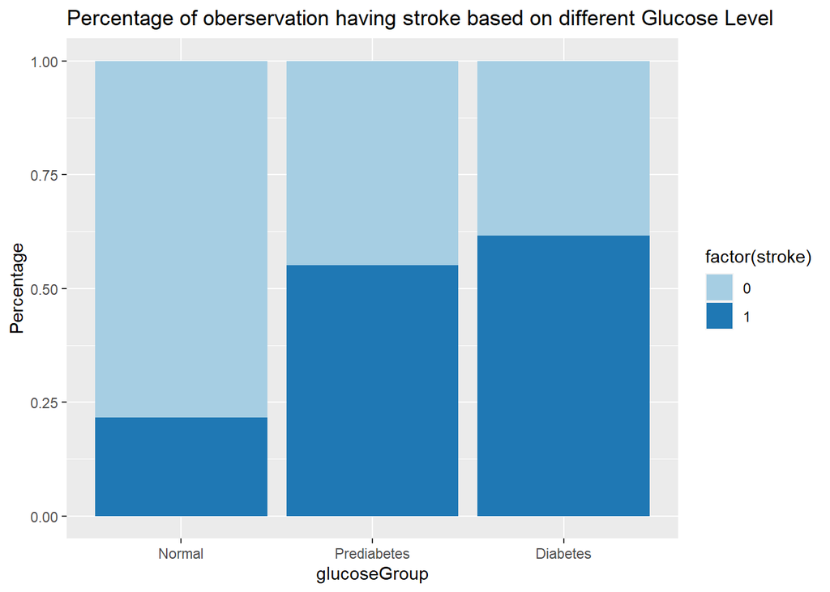

```r
#new values for glucose groups were gene
cleanData$glucoseGroup=cut(cleanData$avg_glucose_level, c(0, 114, 140, Inf), c("Normal", "Prediabetes", "Diabetes"), include.lowest=TRUE)
df_glucose <- cleanData %>%
  group_by(glucoseGroup, stroke) %>%
  count(stroke)
#grouping data into three glucose level

df_glucose %>%
ggplot(mapping = aes(x = glucoseGroup, y = n, fill = factor(stroke))) +
  geom_bar(stat = "identity", position = "fill") +
  labs(title = "Percentage of oberservation having stroke based on different Glucose Level",
       x = "glucoseGroup",
       y = "Percentage") +
  scale_fill_brewer(palette = "Paired")
```

**Glucose Level versus Stroke**

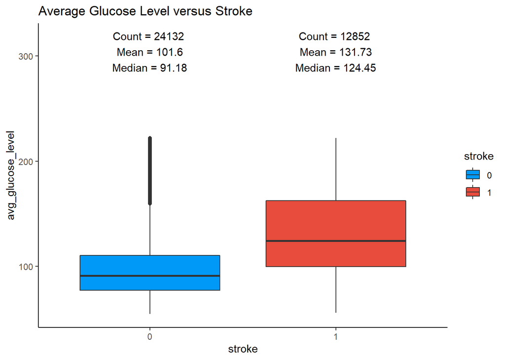

```r
get_box_stats <- function(y, upper_limit = max(brainData$avg_glucose_level) * 1.15) {
  return(data.frame(
    y = 0.95 * upper_limit,
    label = paste(
      "Count =", length(y), "\n",
      "Mean =", round(mean(y), 2), "\n",
      "Median =", round(median(y), 2), "\n"
    )
  ))
}

ggplot(cleanData, aes(x = stroke, y = avg_glucose_level, fill = stroke)) +
  geom_boxplot() +
  labs(title = "Average Glucose Level versus Stroke")+
  scale_fill_manual(values = c("#0099f8", "#e74c3c", "#2ecc71")) +
  stat_summary(fun.data = get_box_stats, geom = "text", hjust = 0.5, vjust = 0.9) +
  theme_classic()
```

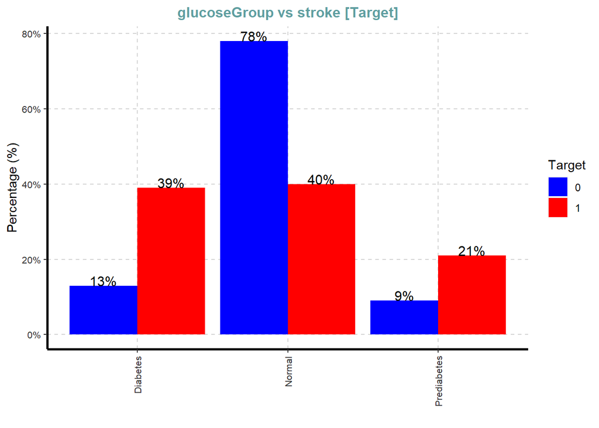

```r
# percent of people with and without stroke for glucose level in three categories
ExpCatViz(
  cleanData %>%
    select(stroke, glucoseGroup),
  target="stroke",col=c("Blue", "red"))
```

As seen above, average glucose level or diabetic level of sugar is impacting the percentage of people with strokes and not. The difference is huge for Diabetic Category  
So as seen from above graphs, glucose level is having direct impact on stroke.

### Age Analysis

**Age Distribution**

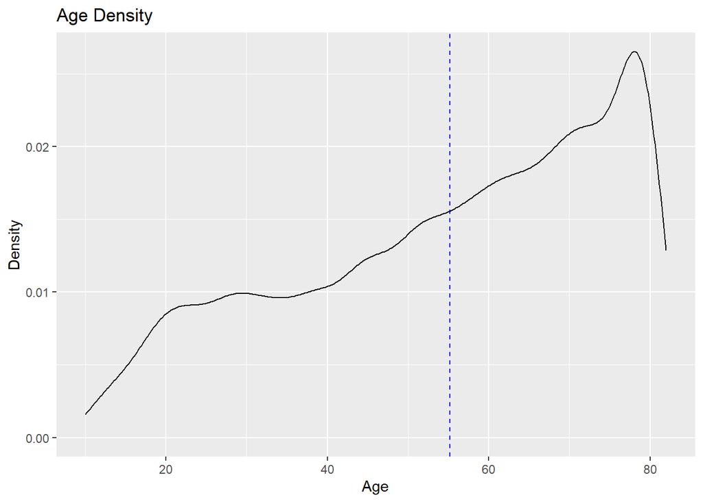

```r
ggplot(cleanData, aes(x = age)) +
geom_density() +
geom_vline(aes(xintercept=mean(age)), color = "blue", linetype = "dashed") +
labs(title = "Age Density", x = "Age", y = "Density")
```

**Distribution of Age for the two Genders Male and Female** Since age could differ around the two genders, and our analysis could only be dependent on age.  
We will compare the age distribution for Male and Female. And as observed from the below graph distribution for Male and Female is similar

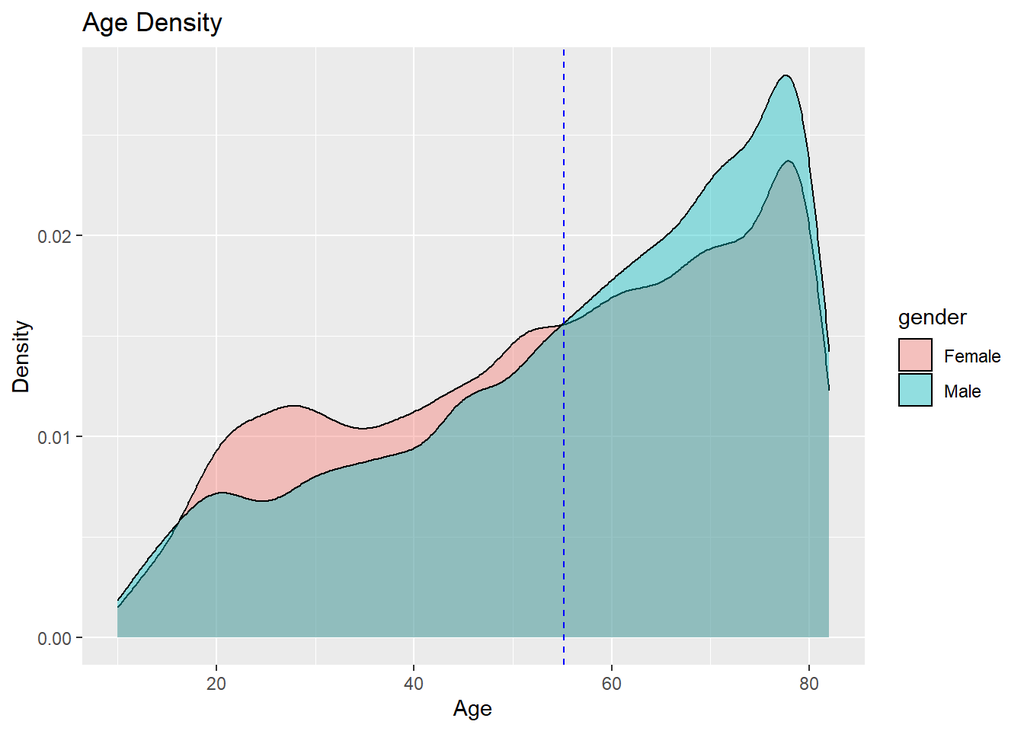

```r
ggplot(cleanData, aes(x = age, fill = gender)) +
geom_density(alpha = 0.4) +
geom_vline(aes(xintercept=mean(age)), color = "blue", linetype = "dashed") +
labs(title = "Age Density", x = "Age", y = "Density")
```

### Age vs stroke

From the below graph, we can see that people who are old are more prone to getting stroke.

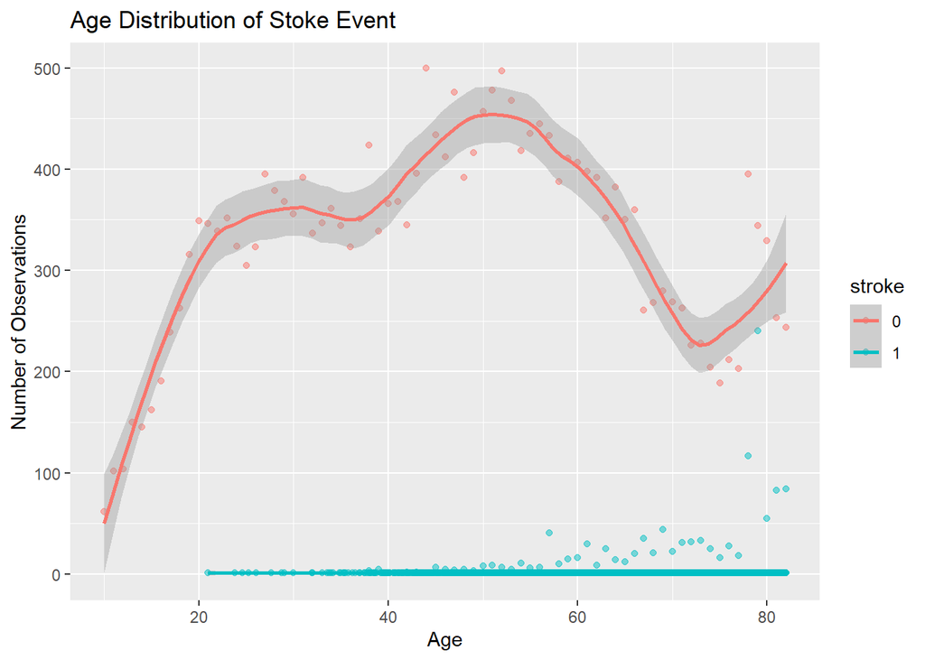

```r
tempdf <- cleanData %>%
  group_by(age, stroke) %>%
  count(stroke)

 tempdf %>%
  ggplot(mapping = aes(x = age, y = n, color = stroke)) +
  geom_point(alpha=0.5) +
  geom_smooth(method = "loess", span = 0.3) +
  labs(title = "Age Distribution of Stoke Event",
       x = "Age",
       y = "Number of Observations")
```

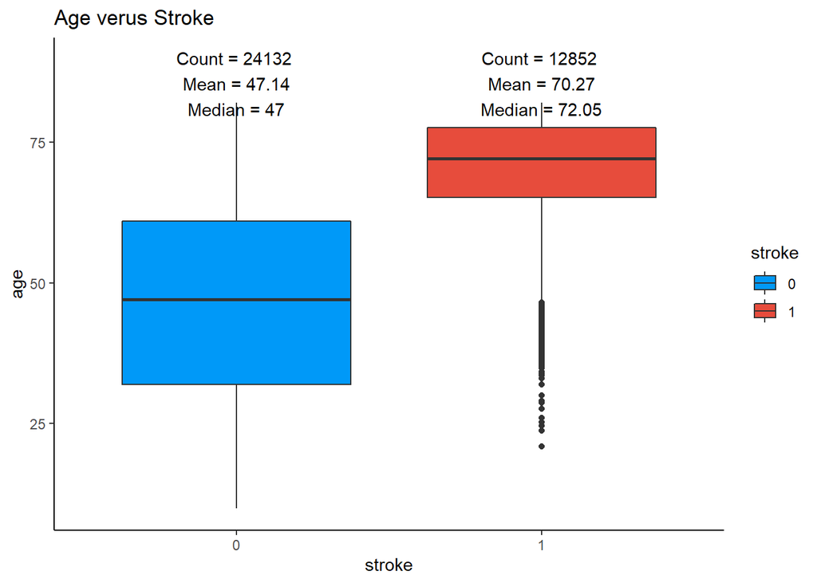

```r
get_box_stats <- function(y, upper_limit = max(cleanData$age) * 1.15) {
  return(data.frame(
    y = 0.95 * upper_limit,
    label = paste(
      "Count =", length(y), "\n",
      "Mean =", round(mean(y), 2), "\n",
      "Median =", round(median(y), 2), "\n"
    )
  ))
}

ggplot(cleanData, aes(x = stroke, y = age, fill = stroke)) +
  geom_boxplot() +
  labs(title = "Age verus Stroke")+
  scale_fill_manual(values = c("#0099f8", "#e74c3c", "#2ecc71")) +
  stat_summary(fun.data = get_box_stats, geom = "text", hjust = 0.5, vjust = 0.9) +
  theme_classic()
```

### Checking Normality after Data Cleaning

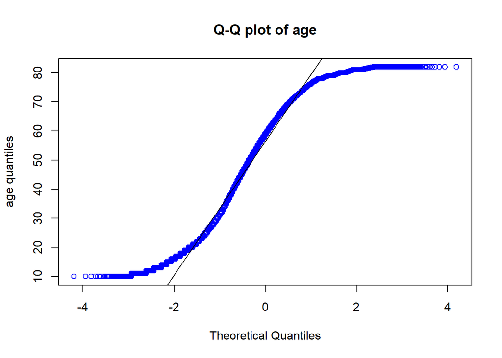

```r
## Q-Q Plot to check normality of Numeric Variables

qqnorm(cleanData$age, main="Q-Q plot of age", col="blue", ylab="age quantiles")
qqline(cleanData$age)
```

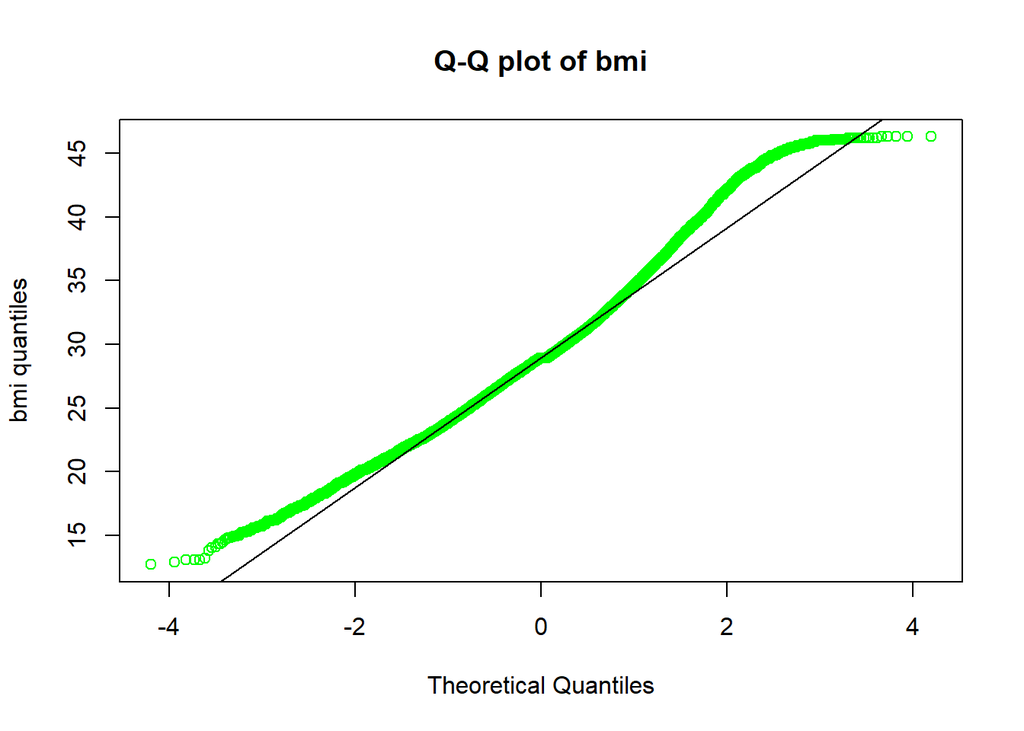

```r
qqnorm(cleanData$bmi, main="Q-Q plot of bmi", col="green", ylab="bmi quantiles")
qqline(cleanData$bmi)
```

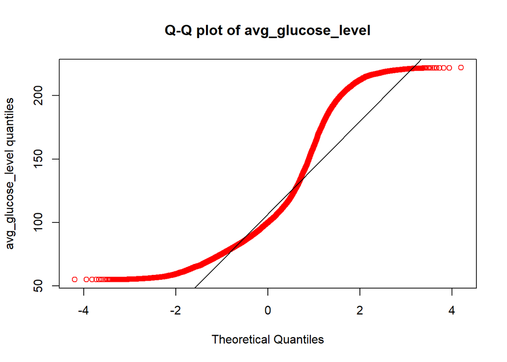

```r
qqnorm(cleanData$avg_glucose_level, main="Q-Q plot of avg_glucose_level", col="red", ylab="avg_glucose_level quantiles")
qqline(cleanData$avg_glucose_level)
```

### Checking Correlation between Numeric Variables

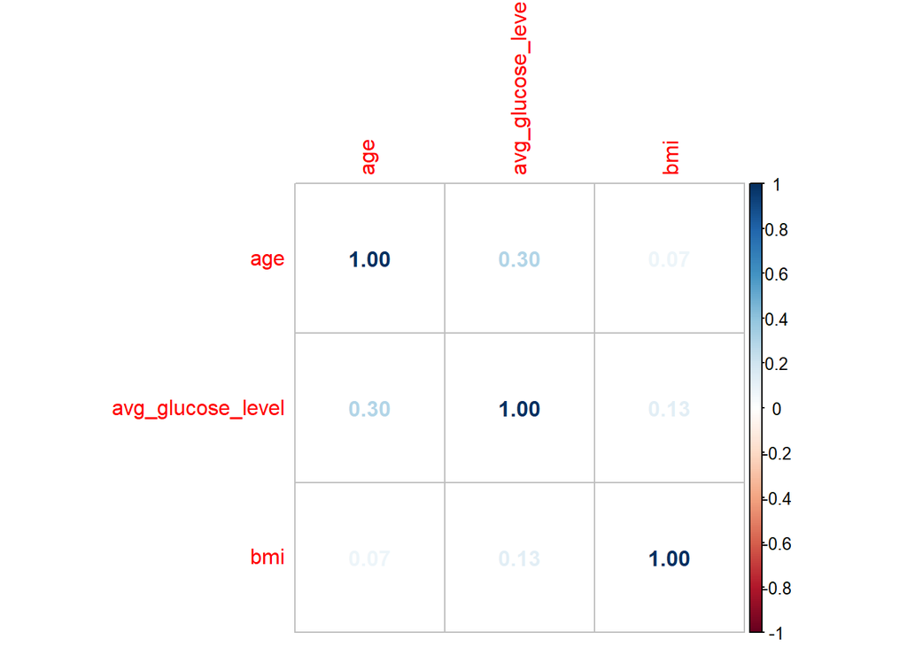

```r
#correlation

corr_data <- select_if(cleanData, is.numeric)
cor_mat <- cor(corr_data)
corrplot(cor_mat,method="number")
```

As seen from the above plot, average glucose level and age are slightly correlated

### SMART Question 3 : Are glucose levels, and BMI correlated to each other?

**BMI and Glucose Level Correlation** The box plot are similar for the three glucose groups, so Not much correlation is observed.

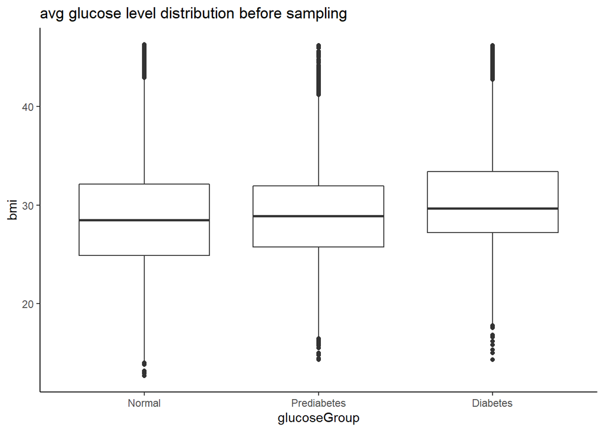

```r
get_box_stats1 <- function(y, upper_limit = max(bmi) * 1.15) {
  return(data.frame(
    y = 0.95 * upper_limit,
    label = paste(
      "Count =", length(y), "\n",
      "Mean =", round(mean(y), 2), "\n",
      "Median =", round(median(y), 2), "\n"
    )
  ))
}

ggplot(cleanData, aes(x = glucoseGroup, y = bmi)) +
  geom_boxplot() +
  labs(title = "avg glucose level distribution before sampling")+
  scale_fill_manual(values = c("#0099f8", "#e74c3c", "#2ecc71")) +
  stat_summary(fun.data = get_box_stats1, geom = "text", hjust = 0.5, vjust = 0.9) +
  theme_classic()
```

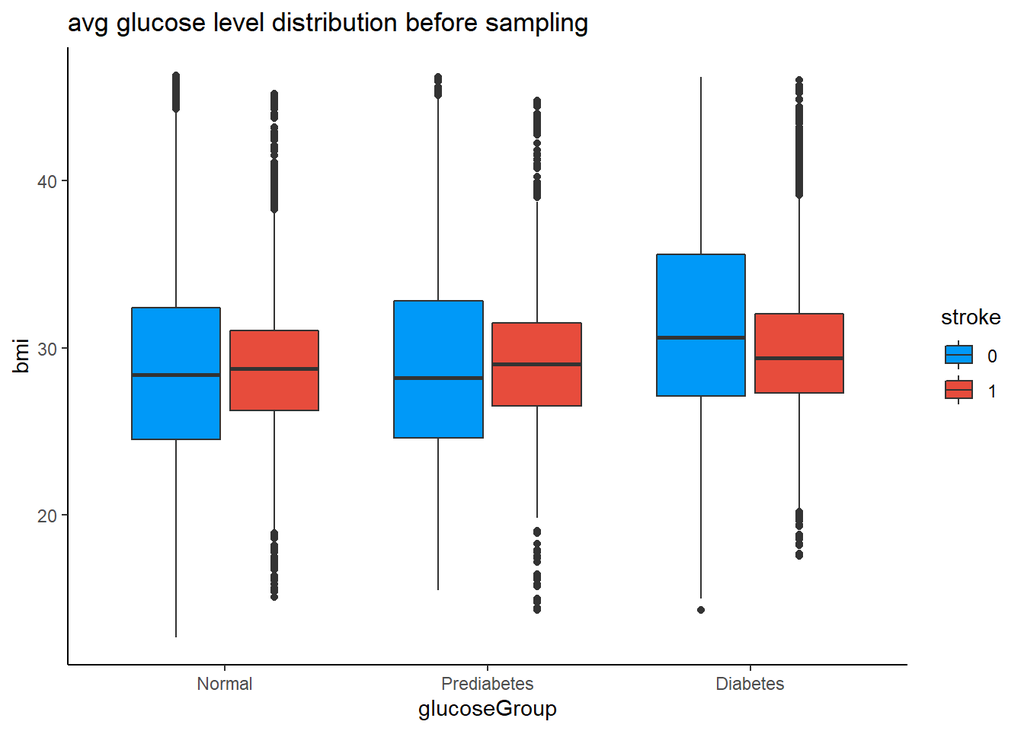

```r
ggplot(cleanData, aes(x = glucoseGroup, y = bmi, fill = stroke)) +
  geom_boxplot() +
  labs(title = "avg glucose level distribution before sampling")+
  scale_fill_manual(values = c("#0099f8", "#e74c3c", "#2ecc71")) +
  stat_summary(fun.data = get_box_stats1, geom = "text", hjust = 0.5, vjust = 0.9) +
  theme_classic()
```

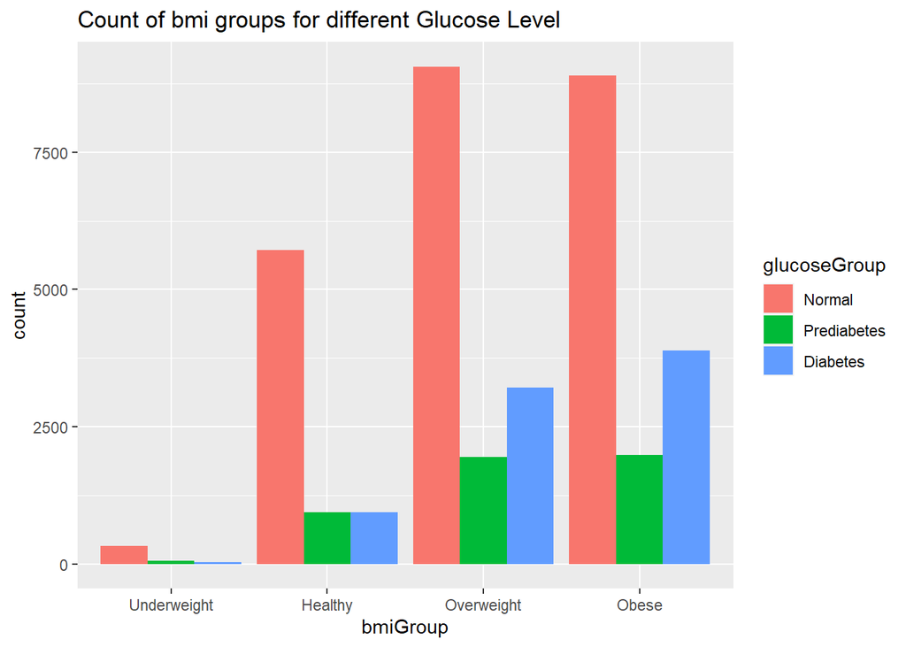

```r
cleanData$bmiGroup=cut(cleanData$bmi, c(0, 18.5, 24.9, 29.9,Inf), c("Underweight", "Healthy", "Overweight","Obese"), include.lowest=TRUE)



#If your BMI is less than 18.5, it falls within the underweight range.
#If your BMI is 18.5 to 24.9, it falls within the normal or Healthy Weight range.
#If your BMI is 25.0 to 29.9, it falls within the overweight range.
#If your BMI is 30.0 or higher, it falls within the obese range.

ggplot(cleanData, aes(x=bmiGroup, fill=glucoseGroup)) + geom_bar(position="dodge")+
  labs(title = "Count of bmi groups for different Glucose Level")
```

```r
#ggplot(cleanData, aes(x=bmi, y=avg_glucose_level, color=stroke)) + geom_point()+
#labs(title = "Average Glucose Level versus Age color coded with stroke", x = "BMI", y = "Average Glucose Level")

#ggplot(cleanData, aes(x=bmi, y=avg_glucose_level, color=stroke)) + geom_point() + facet_grid(~glucoseGroup)
```

As opposed to medical results as seen from above graphs, the glucoseGroups/avg_glucose_level and bmi values/ranges are not correlated for this particular dataset as observed from the graph.  
Correlation value using pearson test : $0.13$

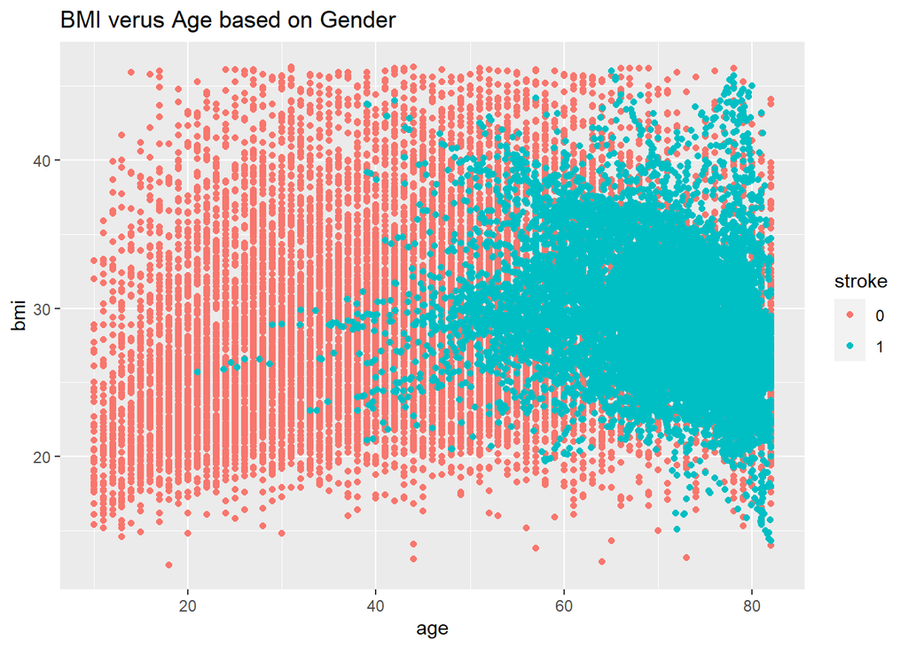

```r
ggplot(cleanData, aes(x=age, y=bmi, color=stroke)) + geom_point()+
    labs(title = "BMI verus Age based on Gender")
```

No strong relation is observed from the scatter plot as well

### Correlation matrix for categorical variables

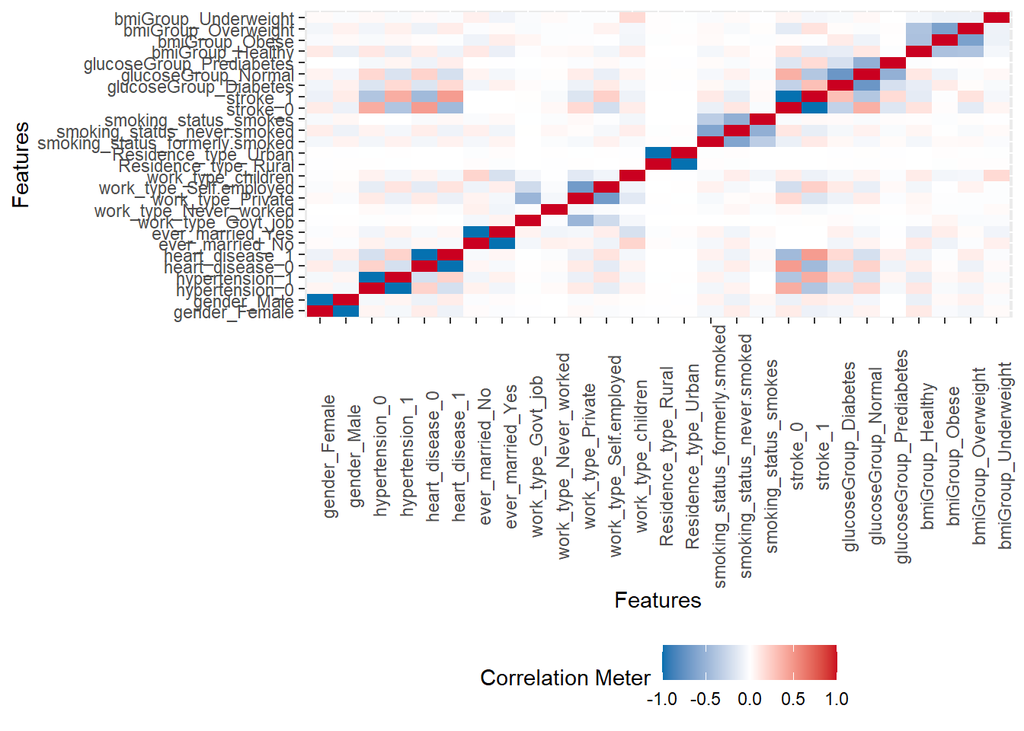

```r
df_character <- select_if(cleanData, is.factor)
#head(df_character)
plot_correlation(df_character)
```

**Data Analysis for Residence Type**

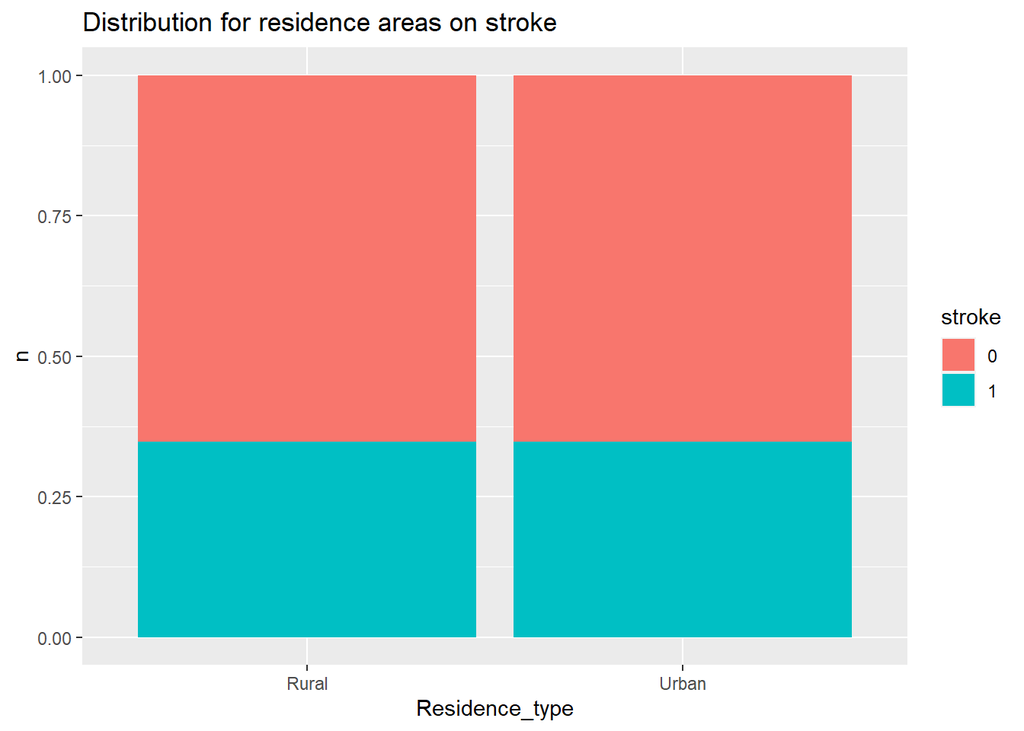

```r
select_res <- select(cleanData, c('Residence_type','stroke'))

res_effect <- select_res %>%
  group_by(Residence_type, stroke) %>%
  count(stroke)

ggplot(res_effect, aes(Residence_type, n, fill = stroke)) +
  geom_bar(stat = 'identity', position='fill') +
  ggtitle("Distribution for residence areas on stroke")
```

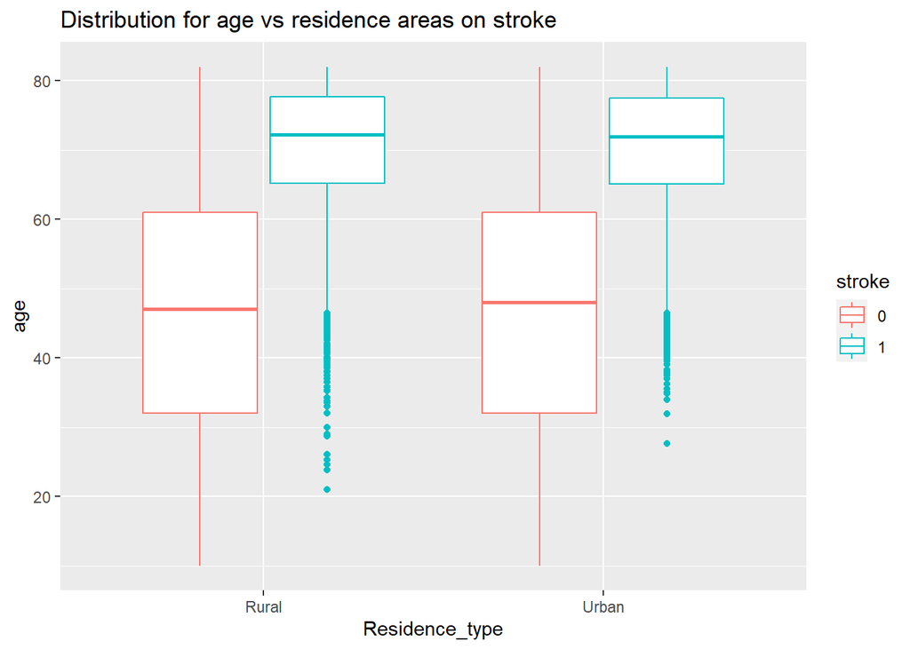

```r
ggplot(cleanData, aes(Residence_type, age, color = stroke)) +
  geom_boxplot() +
  ggtitle("Distribution for age vs residence areas on stroke")
```

```r
recycleData <- select(cleanData, -c('Residence_type'))
head(recycleData)
```

```
##       gender age hypertension heart_disease ever_married     work_type
## 40014 Female  11            0             0           No      children
## 3983    Male  46            0             0          Yes       Private
## 785     Male  79            0             0          Yes Self-employed
## 4237  Female  41            0             0           No       Private
## 32096 Female  61            0             0          Yes       Private
## 4042  Female  50            0             0          Yes       Private
##       avg_glucose_level  bmi  smoking_status stroke glucoseGroup   bmiGroup
## 40014            107.09 28.9 formerly smoked      0       Normal Overweight
## 3983             114.46 24.7 formerly smoked      0  Prediabetes    Healthy
## 785              116.67 33.5    never smoked      0  Prediabetes      Obese
## 4237              76.08 25.1    never smoked      0       Normal Overweight
## 32096             74.99 45.5 formerly smoked      0       Normal      Obese
## 4042             103.72 35.4 formerly smoked      0       Normal      Obese
```

From the plots above for residence types, we notice that residence type has no effect at all on strokes. Thsi is why we are dropping the residence column, there is no use for it in our data analysis.

### Data Analysis for Heart Disease

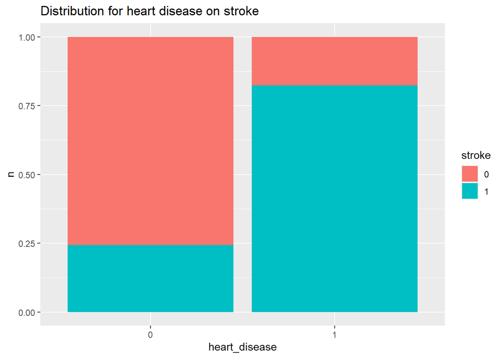

```r
select_heart_disease <- select(recycleData, c('heart_disease','stroke'))

heart_effect <- select_heart_disease %>%
  group_by(heart_disease, stroke) %>%
  count(stroke)

ggplot(heart_effect, aes(heart_disease, n, fill = stroke)) +
  geom_bar(stat = 'identity', position='fill') +
  ggtitle("Distribution for heart disease on stroke")
```

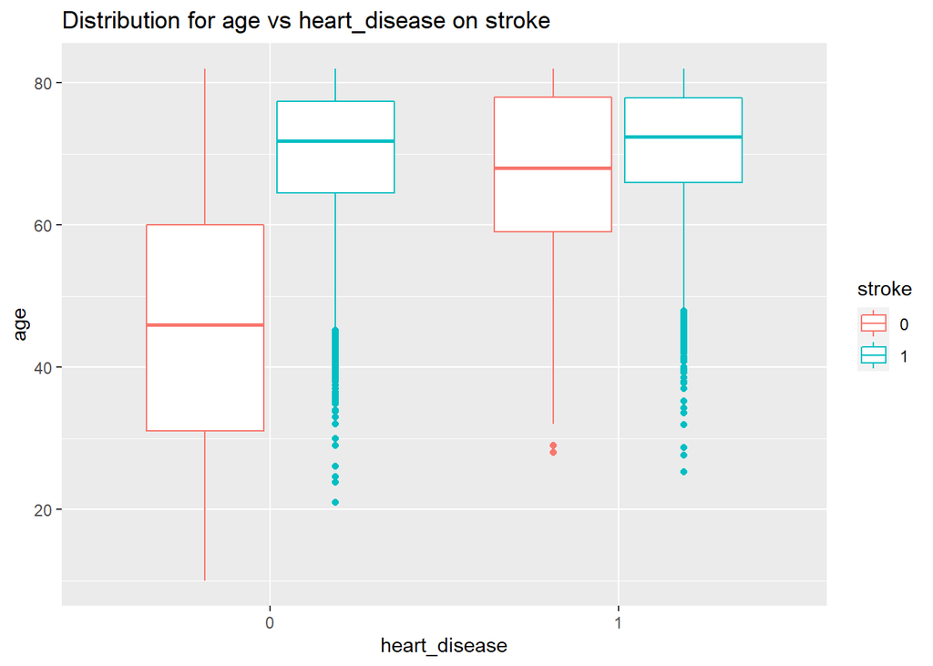

```r
ggplot(recycleData, aes(heart_disease, age, color = stroke)) +
  geom_boxplot() +
  ggtitle("Distribution for age vs heart_disease on stroke")
```

After cleaning the data, the plots above predicts that heart disease might actually have an impact on stroke but age has a bigger factor on stroke. We see that an increase in age comes with an increase in heart disease. This means that people in the higher age bracket are prone to heart diseases than people in the lower age bracket, this is the relation between heart disease and age.

**Data Analysis for Hypertension**

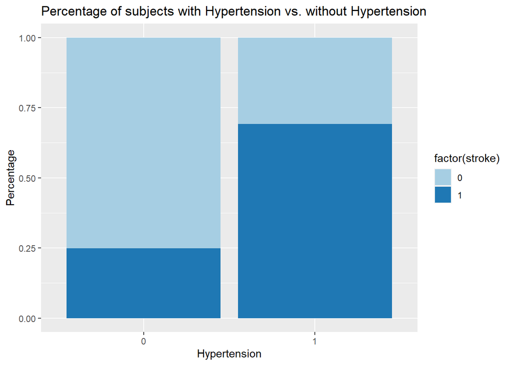

```r
df_hypertension_stroke <- recycleData %>%
  group_by(hypertension, stroke) %>%
  count(stroke)

df_hypertension_stroke %>%
ggplot(mapping = aes(x = hypertension, y = n, fill = factor(stroke))) +
  geom_bar(stat = "identity", position = "fill") +
  labs(title = "Percentage of subjects with Hypertension vs. without Hypertension",
       x = "Hypertension",
       y = "Percentage") +
  scale_fill_brewer(palette = "Paired")
```

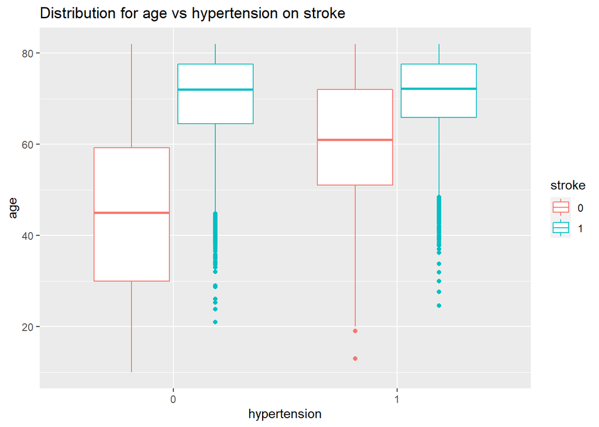

```r
ggplot(recycleData, aes(hypertension, age, color = stroke)) +
  geom_boxplot() +
  ggtitle("Distribution for age vs hypertension on stroke")
```

As we can see from the graph that the number of hypertension cases increases with the age due to multiple biological factors.  
From the above charts, we see that the number of strokes is correlated to the hypertension status of the subject. But hypertension is in-turn correlated to age.